# Las siete nuevas herramientas de control de calidad

Las siete nuevas herramientas de QC se utilizan ampliamente como métodos para manejar principalmente datos lingüísticos en la resolución de problemas y el logro de objetivos.

- Explicación, propósito, creación y uso de las Siete Nuevas Herramientas de Control de Calidad.
- Interpretación de los diagramas resultantes de las Siete Nuevas Herramientas de Control de Calidad.
- Método para el despliegue sistemático utilizando el Diagrama de Árbol (o Diagrama Sistemático)
- Explicación de la predicción previa y el despliegue del proceso del Método PDPC.
- Cálculo de cada fecha del método de Diagrama de Flechas.
- Explicación del significado del análisis de datos matriciales (Método de Análisis de Componentes Principales).

[Audio_1](https://drive.google.com/file/d/1Y5rVkUSqzdRP9yzE1bsB35zFXM8T9Ans/view?usp=drive_link)

```python
import os, sys

try:
  os.chdir('../Python/QCKentei3')
except:
  pass

sys.path.append(os.path.abspath(os.path.join("..","Common")))
path = os.getcwd()
```

```python
import numpy as np
import pandas as pd
import matplotlib.pyplot as plt
```

## 03-01 Método de afinidad

親和図法

### 1. Métodos de afinidad y su aplicación

親和図法とその適用

El método de afinidad es una técnica que permite capturar hechos, opiniones e ideas a través de datos lingüísticos para abordar problemas inciertos, como aquellos relacionados con el futuro, cuestiones emergentes o problemas desconocidos y no experimentados previamente. Posteriormente se organiza un diagrama integrando estos datos según su afinidad mutua, lo que ayuda a clarificar la naturaleza y ubicación de los problemas que deben resolverse.

1. Quisiera organizar la información obtenida de entrevistas con clientes para comprender sus necesidades.
2. Quisiera analizar las opiniones de los clientes obtenidas a través de encuestas para utilizarlas en el desarrollo de productos.
3. Quisiera consolidar y resumir las ideas generadas en la lluvia de ideas.
4. Quisiera recopilar las opiniones de los clientes, como consultas y reclamaciones, y presentarlas de forma clara para su comunicación.
5. Quisiera clarificar los puntos fuertes y débiles de la situación actual de las propuestas de mejora internas.
6. Los problemas a mejorar y sus asuntos relacionados son diversos y complejos, por lo que quisiera poder comprender y visualizar el panorama general para así revelar la estructura de estos problemas complejos.
7. Quisiera resumir el contenido del plan de gestión a medio y largo plazo y las perspectivas futuras de la organización mediante una lluvia de ideas, para poder utilizarlo en la elaboración y despliegue de estrategias futuras.

[Audio_2](https://drive.google.com/file/d/1UVlq8ma6SV3tA22mPvYW-uQ5kvls3pau/view?usp=drive_link)

### 2. Cómo crear un diagrama de afinidad

親和図のつくり方

Paso 1: Definir el tema テーマを決める

Paso 2: Recopilar datos lingüísticos 言語データを収集する

Paso 3: Crear tarjetas de datos データカードを作る

Paso 4: Agrupar las tarjetas カード寄せをする

Paso 5: Crear tarjetas de afinidad 親和カードを作る

Paso 6: Repetir el proceso de agrupación de tarjetas y creación de tarjetas de afinidad カード寄せと親和カード作りを繰り返す

Paso 7: Finalizar el diagrama de afinidad 親和図を仕上げる

[Audio_3](https://drive.google.com/file/d/1DgY30e6FvIup2u1rJ_NAar8rQdUxfCpN/view?usp=drive_link)

#### La Figura 3.1 ilustra un caso donde se llevó a cabo una tormenta de ideas para resumir y estandarizar la concepción del estado deseable de las operaciones de venta en un distribuidor de vehículos.

[Audio_4](https://drive.google.com/file/d/116AKoY4tv9-Ss3WgageFjTblPZyzoWl8/view?usp=drive_link)

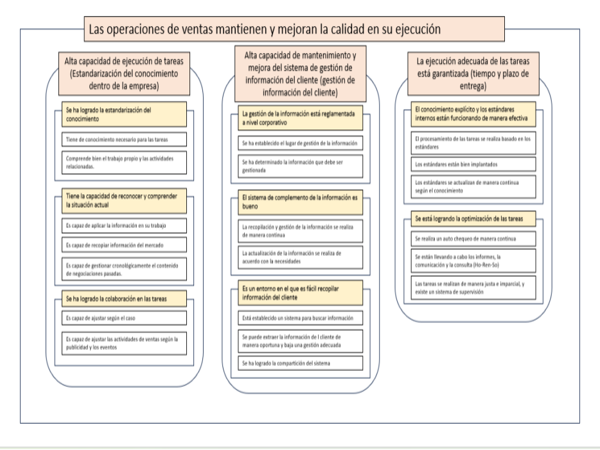

```python
from IPython.display import display
from PIL import Image

img = Image.open('Graph3/Afinidad.png')
# サイズを指定（幅x高さ）
resized_img = img.resize((600, 450))  # (width, height)

display(resized_img)
```

## 03-02 Método de diagrama de relaciones

連関図法

### 1. Método de diagrama de relaciones y su aplicación

連関図法とその適用

El método de diagrama de relaciones es una herramienta para analizar problemas en los que las relaciones de causa-efecto o propósito-medio están intrincadamente entrelazadas. Consiste en conectar lógicamente estas relaciones causales para esclarecer la esencia del problema.

El Diagrama de Relaciones se utiliza para encontrar el hilo conductor de la solución. Para usarlo, se extraen las causas y luego se repite la extracción de las causas de esas causas, diagramando las relaciones causales de manera que puedan verse de un vistazo. A diferencia del Diagrama de Causa-Efecto, el Diagrama de Relaciones también permite mostrar las relaciones entre los factores, como causa-efecto u objetivo-medio, mediante flechas.

El Diagrama de Relaciones se puede aplicar en situaciones donde se desea aclarar la imagen general, comprender los factores, o revelar la estructura, como en la planificación de la estrategia empresarial, el desarrollo de nuevos productos, la identificación de las causas de defectos en el proceso de fabricación, la revisión del sistema de servicio al cliente y el análisis de reclamaciones.

1. Quisiera investigar las causas de los defectos o las fallas.
2. Quisiera esclarecer la estructura del problema.
3. Quisiera esclarecer los medios para alcanzar el objetivo.

[Audio_5](https://drive.google.com/file/d/10COHaNAQCOSoHgwROc_AMhuLemTaw0P3/view?usp=drive_link)

### 2. Cómo crear un diagrama de relaciones

連関図のつくり方

Paso 1: Definir el tema. テーマを決める

Paso 2: Escribir en tarjetas los elementos relacionados con el tema. テーマに関する項目をカードに書く

Paso 3: Determinar los "problemas" basados en el tema y distribuir las tarjetas de datos. テーマに基づいて「問題点」を決め、データカードを広げる

Paso 4: Identificar las causas primarias. １次原因を考える

Paso 5: Analizar las causas de cada causa primaria. １次原因ごとに原因を追究する

Paso 6: Examinar las relaciones causales entre los diferentes faciles. 原因相互の因果関係を追究する

Paso 7: Verificar las relaciones causales entre los factores. 原因相互の因果関係を確認する

Paso 8: Identificar la causa principal. 主要原因を突き止める

[Audio_6](https://drive.google.com/file/d/1tTjDCi6ueQdpm2wONoePkCFdAQ1fUnqy/view?usp=drive_link)

#### Figura 3.2 Diagrama de relaciones de la imposibilidad de expandir la cuota de mercado

[Audio_7](https://drive.google.com/file/d/1KCRAiCPXAf1QS9w7IVMlBe-u_jl8GQmU/view?usp=drive_link)

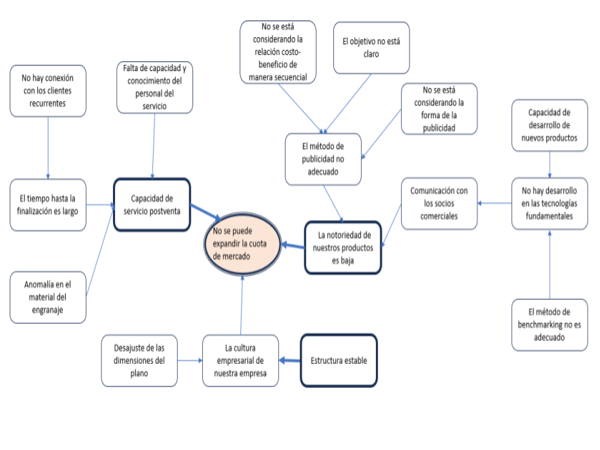

```python
img = Image.open('Graph3/Relaciones.png')
# サイズを指定（幅x高さ）
resized_img = img.resize((600, 450))  # (width, height)

display(resized_img)
```

## 03-03 Método del diagrama sistemático

系統図法

### 1. Método del diagrama sistemático y su aplicación

系統図法とその運用

- El método del diagrama sistemático es una técnica que aplica el concepto y la elaboración del diagrama funcional utilizado en el análisis funcional de VE. Consiste en establecer objetivos, metas y resultados finales, y desarrollar sistemáticamente los medios y estrategias necesarios para alcanzarlos.
1. Quisiera obtener propuestas de soluciones viables para resolver los problemas y desafíos.
2. Quisiera especificar las acciones que cada departamento y cada responsable deben llevar a cabo.
- Tipo de desarrollo de estrategias: Se denomina diagrama estadístico que despliega los objetivos y los medios en múltiples niveles de ramificación para obtener estrategias factibles.
- Tipo de desarrollo de elementos constitutivos: Es un diagrama de árbol que clarifica las relaciones de inclusión y las interrelaciones de los elementos de un objeto. Existen diferentes tipos, como el diagrama de árbol de funciones, el diagrama de árbol de calidad y el diagrama de árbol de causa-efecto.

### 2. Cómo hacer un diagrama sistemático

系統図のつくり方

Tipo de desarrollo de estrategias

Paso 1: Determinar el objetivo principal basado en el tema. テーマに基づいて基本目的を決める

Paso 2: Considerar los medios de primer nivel. １次手段を考える

Paso 3: Pensar en los medios de segundo nivel y posteriores ２次以降の手段を考える

Paso 4: Conectar con líneas la relación entre el objetivo y los medios. 目的と手段の関係を線でつなぐ

Paso 5: Finalizar el diagrama sistemático 系統図を仕上げる

Paso 6: Seleccionar los medios viables para su implementación 実行可能な手段を絞り込む

[Audio_8](https://drive.google.com/file/d/1y-Ttl4MS33EeGMnodfSBX1ZK_Q75M6TB/view?usp=drive_link)

#### Figura 3.3 Ejemplo de diagrama sistemático para crear una organización capaz de abordar y prevenir problemas de calidad

[Audio_9](https://drive.google.com/file/d/1p37YeCQctvf7WDsHLuQcwCOfm8ib31No/view?usp=drive_link)

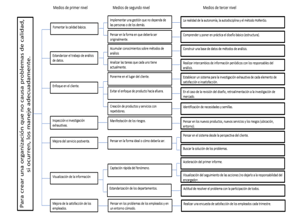

```python
img = Image.open('Graph3/Sistemático.png')
# サイズを指定（幅x高さ）
resized_img = img.resize((600, 450))  # (width, height)

display(resized_img)
```

## 03-04 Método del diagrama de matriz

マトリックス図法

### 1. Método del diagrama de matriz su aplicación

マトリックス図法とその運用

El método del diagrama de matriz se utiliza para aclarar los problemas a través del pensamiento multidimensional. Especialmente, se emplea para explorar la ubicación o forma del problema dentro de un diseño binario, o para obtener ideas para la solución del problema. También se usa para organizar las relaciones entre múltiples elementos, como entre causas y resultados, o entre diferentes factores.

### 2. Cómo hacer un diagrama de matriz

マトリックス図のつくり方

Paso 1: Determinar el tema テーマを決める

Paso 2: Decidir los elementos a combinar y considerar 組み合わせて考える事柄を決める

Paso 3: Elegir el tipo de diagrama de matriz マトリックス図の型をえらぶ

Paso 4: Decidir los elementos a ubicar en cada eje 各軸に配する要素を決める

Paso 5: Determinar la existencia o el grado de relación 関連の有無あるいは関連の度合いを決める

Paso 6: Obtener puntos de enfoque 着眼点を得る

[Audio_10](https://drive.google.com/file/d/17CQ-jsjgPTAYRSqdqngWQ8eKJZP-A2Yj/view?usp=drive_link)

#### Figura 3.4 Tabla de calidad del cortador de nuevo producto mediante el diagrama de matriz en forma de L

[Audio_11](https://drive.google.com/file/d/1b5a3D-chDMJPSiGDR5NBacYmwOqePLC3/view?usp=drive_link)

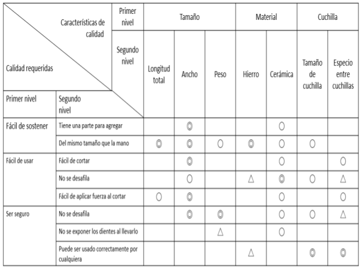

```python
img = Image.open('Graph3/Matrís.png')
# サイズを指定（幅x高さ）
resized_img = img.resize((600, 450))  # (width, height)

display(resized_img)
```

## 03-05 Método del diagrama de flechas

アローダイアグラム

### 1. Método del diagrama de flechas y su aplicación

アローダイアグラム法とその適用

El método del diagrama de flechas es un diagrama que utiliza flechas para representar la planificación del cronograma.

PERT (Programa Evaluation and Review Technique): Se utiliza para la planificación de cronogramas y la gestión del progreso. Representa las relaciones entre las tareas necesarias para llevar a cabo un plan específico mediante una red, con el fin de establecer una planificación óptima del cronograma y gestionar el progreso de manera eficiente.

El Método del Diagrama de Flechas (ADM) es una técnica que representa las relaciones de precedencia entre las tareas necesarias para llevar a cabo un proyecto mediante flechas y nodos, con el fin de crear una planificación óptima del cronograma, identificar los puntos críticos para la gestión del progreso y administrar eficientemente el avance del plan.

### 2. Cómo hacer un diagrama de flechas

アローダイアグラムのつくり方

Paso 1: Determinar las tareas necesarias para el plan y la duración requerida. 計画に必要な作業と所要時間を決める

Paso 2: Crear tarjetas de tareas. 作業カードを作る

Paso 3: Establecer el orden de relación entre las tarjetas de tareas. 作用カードの相互の順序関係をつける

Paso 4: Disponer las tarjetas de tareas. 作業カードを配置する

Paso 5: Conectar con líneas de unión y flechas. 結合点を入れて矢印でつなぐ

Paso 6: Asignar números de los puntos de unión. 結合点番号を付ける

Paso 7: Calcular los tiempos de los puntos de unión más tempranos y más tardíos para determinar la **ruta crítica**. 最早・最遅結合点日程を計算してクリティカルパスを求める

[Audio_12](https://drive.google.com/file/d/1Kr7cvaJM1kK-GFvhYxtY-c2b9D0F0_L9/view?usp=drive_link)

#### Figura 3.5 Diagrama de Flechas del Proceso de Estudio para el Examen de Certificación QC Nivel 3.

[Audio_13](https://drive.google.com/file/d/1tV6e1NbkkAvnI2BBjVBq1BQTKUqDojpO/view?usp=drive_link)

```
Diagrama de flechas del Proyecto X
```

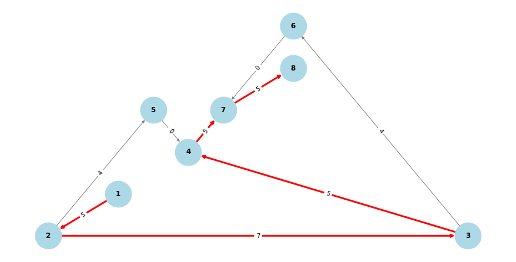

[output not shown]

```python
import draw_pert_graph
import networkx as nx

# Creación del gráfico
graph = nx.DiGraph()

# Plan de Elaborar un plan de estudio
graph.add_weighted_edges_from([
    (1, 2, 5),  # Capitulo 0 - Capitulo 1, 5 semanas
    (2, 3, 7),  # Capitulo 2 - Capitulo 4, 7 semanas
    (2, 5, 4),  # Repaso del nivel 4, 4 semanas
    (3, 4, 5),  # Capitulo 5 - Capitulo 7, 5 semanas
    (3, 6, 4),  # Practicar con preguntas de exámenes, 4 semanas
    (4, 7, 5),  # Capitulo 8 - Capitulo 9, 5 semanas
    (5, 4, 0),  # Dummy
    (6, 7, 0),  # Dummy
    (7, 8, 5)   # Capitulo 10 - Capitulo 12, 5 semanas
])

# Cálculo del calendario de unión más temprano (ruta hacia adelante)
earliest_times = {node: 0 for node in graph.nodes()}
for node in nx.topological_sort(graph):
    for succ in graph.successors(node):
        earliest_times[succ] = max(earliest_times[succ], earliest_times[node] + graph[node][succ]['weight'])

# Cálculo del calendario de unión más tardío (ruta hacia atrás)
latest_times = {node: earliest_times[max(graph.nodes())] for node in graph.nodes()}
for node in reversed(list(nx.topological_sort(graph))):
    for pred in graph.predecessors(node):
        latest_times[pred] = min(latest_times[pred], latest_times[node] - graph[pred][node]['weight'])


# Identificación del camino crítico
critical_path = []
for node in graph.nodes():
    for succ in graph.successors(node):
        if earliest_times[node] == latest_times[node] and earliest_times[succ] == latest_times[succ]:
            critical_path.append((node, succ))

print('Diagrama de flechas del Proyecto X')
# Representar el gráfico
draw_pert_graph.draw_pert_graph(graph, critical_path)


# Cálculo de la ruta crítica
critical_path = nx.algorithms.dag.dag_longest_path(graph, weight='weight')
critical_path_length = nx.algorithms.dag.dag_longest_path_length(graph, weight='weight')
critical_path_length_before = critical_path_length

print(f"Ruta crítica: {' -> '.join(map(str, critical_path))}")
print(f"Todas las tareas: {critical_path_length} Semanas")
```

## 03-06 Método PDPC

ＰＤＰＣ法

### 1. Método PDPC y su aplicación

ＰＤＰＣ法とその運用

El método PDPC es un diagrama de planificación de procesos decisionales, que permite prever diversos resultados posibles con antelación y guiar el desarrollo del proceso en la dirección más favorable posible.

Representa una serie de pasos hasta la resolución de un problema y se utiliza cuando se anticipan posibles obstáculos y se toman las medidas adecuadas de antemano. Es una técnica para prever diversas situaciones en el curso de un proyecto y describir el flujo de las acciones para abordarlas.

1. Cuando la situación es fluida y la predicción o la previsión son difíciles, quisiera planificar según el desarrollo de los acontecimientos en el proceso de implementación y alcanzar el objetivo.
2. El objetivo es definir acciones preventivas para evitar que se produzca una situación crítica cuando se anticipan resultados desfavorables.

### 2. Cómo elaborar un diagrama PDPC

ＰＤＰＣ図のつくり方

Paso 1: Determinar el tema テーマを決める

Paso 2: Definir el punto de partida y la meta (objetivo a alcanzar) 出発点とゴール（到達目標）を決める

Paso 3: Elaborar un plan de acción en el punto de partida. 出発点での着手計画を立てる

Paso 4: Desarrollar progresivamente el plan. 計画を遂次充実する

Paso 5: Indicar la finalización del plan. 計画の完了を表示する

[Audio_14](https://drive.google.com/file/d/1XYNdft0eoV_o8rTJOLnMU2EYhVhM9bj6/view?usp=drive_link)

#### Figura 3.6 Diagrama PDPC sobre las formas de regresar a casa en caso de encontrarse con una fuerte lluvia mientras se está fuera

[Audio_15](https://drive.google.com/file/d/1WBB4F-7Ywiaw6oAwu9iNUhr_7YM3Yt2E/view?usp=drive_link)

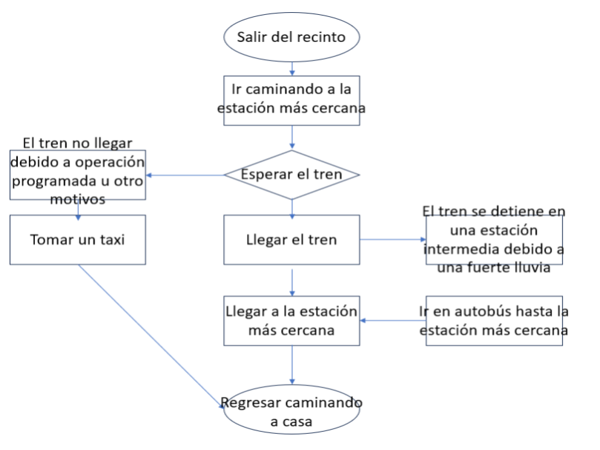

```python
img = Image.open('Graph3/PDPC.png')
# サイズを指定（幅x高さ）
resized_img = img.resize((600, 450))  # (width, height)

display(resized_img)
```

### 03-07 Método de análisis de datos matriciales

マトリックス・データ解析法

### 1. Método de análisis de datos matriciales y su aplicación

マトリックス・データ解析法とその適用

- El método de análisis de datos matriciales consiste en analizar datos numéricos dispuestos en una matriz. Es una técnica de análisis multivariante y también se conoce como análisis de componentes principales.
1. Se han recopilado datos con numerosas escalas (mediciones), pero no se puede captar la tendencia. No se pueden clasificar. Son difíciles de usar como factores. Son demasiado detallados y no se puede explicar de qué se trata en resumen.
2. Quisiera analizar los datos de diversas encuestas para identificar la evaluación y la importancia que los clientes otorgan, así como las posibles vías de mejora.
3. Quisiera consolidar los datos de los elementos de calidad de productos y componentes para identificar los puntos problemáticos en la garantía de calidad.

### 2. Procedimiento de análisis de datos matriciales

マトリックス・データ解析の手順

Paso 1: Organizar los datos en una matriz. データをマトリックス状に整理する

Paso 2: Calcular los valores propios y los vectores propios. 固有値・固有ベクトルを求める

Paso 3: Determinar el número de componentes principales. 主成分の数を決める

Paso 4: Asignar significado a cada componente principal. 各主成分の意味付けを行う

Paso 5: Calcular las puntuaciones de los componentes principales. 主成分得点を求める

Paso 6: Representar gráficamente la distribución de las muestras. サンプルの散布状況を図示する

[Audio_16](https://drive.google.com/file/d/10aTUtFc9IL1-tWh7GiyYOR-hsPoGMiN5/view?usp=drive_link)

#### Figura 3.7

A partir del análisis de datos matriciales realizado con los resultados de las pruebas de habilidad en Lengua, Inglés, Matemáticas y Ciencias de 10 estudiantes, se encontró que el primer componente principal (Componente 1, eje horizontal) representa el rendimiento general de los estudiantes, mientras que el segundo componente principal (Componente 2, eje vertical) refleja la diferencia entre aquellos con fortalezas en ciencias y aquellos con fortalezas en humanidades. Diagramas de dispersión de las cargas factoriales y las puntuaciones de los componentes principales.

[Audio_17](https://drive.google.com/file/d/1EBnKtCfJ8sTBG22ja8uhz10IrywD0JQK/view?usp=drive_link)

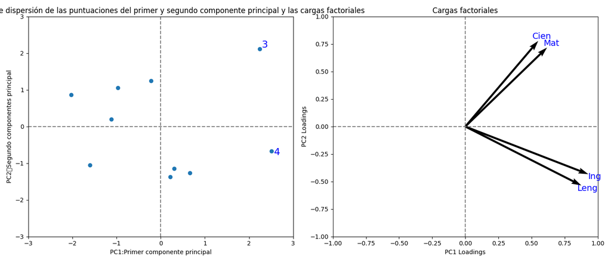

```python
img = Image.open('Graph3/15_3.png')
display(img)
```

## Por favor, responda a las preguntas del examen de práctica a través del siguiente enlace.

[Simulacro de examen](https://forms.gle/ij4yA3imyRaEZv7e8)

```python
notebook_name = 'QCKentei3-3.ipynb'
notebook_name_html = notebook_name.replace(".ipynb",".html")

!jupyter nbconvert --to html {notebook_name}
```

```
[NbConvertApp] Converting notebook QCKentei3-3.ipynb to html
[NbConvertApp] Writing 1486685 bytes to QCKentei3-3.html
```